# mlb_analysis

Elijah Verdoorn

October 16, 2016

# Get Data

```r
allData.df <- read.csv("MLB_1985_2013.csv") # read all the data
allData.df <- allData.df[complete.cases(allData.df),]
trainingData.df <- subset(allData.df, yearID < 2011 & !is.null(Allstar.next) & !is.null(salary) & !is.null(AB)) # get the training data
testingData.df <- subset(allData.df, yearID == 2011 & !is.null(Allstar.next) & !is.null(salary) & !is.null(AB)) # get the data to use to test the models
newData.df <- subset(allData.df, yearID == 2012 & !is.null(Allstar.next) & !is.null(salary) & !is.null(AB)) # get the 2012 testing data
```

Grab our data from the CSV. Once we have it, split up the data so that we have easy access to the testing, training, and new 2012 data.

# Logistic

```r
logisticRegrssionModel <- glm(Allstar.next ~ salary * AB * H * B2 * B3, family = binomial, data = testingData.df)
summary(logisticRegrssionModel)
```

```
##
## Call:
## glm(formula = Allstar.next ~ salary * AB * H * B2 * B3, family = binomial,
##     data = testingData.df)
##
## Deviance Residuals:
##      Min        1Q    Median        3Q       Max
## -2.04988  -0.39553  -0.07958  -0.00881   2.37699
##
## Coefficients:
##                     Estimate Std. Error z value Pr(>|z|)
## (Intercept)       -3.808e+00  4.282e+00  -0.889  0.37385
## salary             1.533e-07  1.014e-06   0.151  0.87987
## AB                -1.693e-01  6.278e-02  -2.697  0.00701 **
## H                  7.384e-01  2.438e-01   3.029  0.00246 **
## B2                -7.856e-01  6.998e-01  -1.123  0.26161
## B3                -3.311e+00  8.827e+00  -0.375  0.70758
## salary:AB          1.764e-08  6.161e-09   2.864  0.00419 **
## salary:H          -7.605e-08  2.452e-08  -3.102  0.00192 **
## AB:H              -1.588e-04  2.206e-04  -0.720  0.47152
## salary:B2          4.989e-08  8.882e-08   0.562  0.57434
## AB:B2              6.579e-03  2.505e-03   2.626  0.00864 **
## H:B2              -1.765e-02  9.153e-03  -1.928  0.05382 .
## salary:B3         -2.678e-06  3.271e-06  -0.819  0.41303
## AB:B3              2.546e-02  2.163e-02   1.177  0.23921
## H:B3              -9.833e-02  9.874e-02  -0.996  0.31932
## B2:B3              2.792e-01  3.538e-01   0.789  0.42995
## salary:AB:H        1.746e-11  3.249e-11   0.537  0.59103
## salary:AB:B2      -6.849e-10  2.602e-10  -2.632  0.00848 **
## salary:H:B2        2.372e-09  9.934e-10   2.388  0.01693 *
## AB:H:B2           -2.589e-06  8.820e-06  -0.293  0.76915
## salary:AB:B3       2.015e-09  6.311e-09   0.319  0.74948
## salary:H:B3        2.849e-08  2.260e-08   1.261  0.20742
## AB:H:B3            4.277e-05  1.476e-04   0.290  0.77198
## salary:B2:B3       6.124e-08  1.023e-07   0.599  0.54940
## AB:B2:B3          -1.138e-03  7.871e-04  -1.446  0.14811
## H:B2:B3            1.800e-03  3.220e-03   0.559  0.57615
## salary:AB:H:B2    -3.686e-13  1.237e-12  -0.298  0.76578
## salary:AB:H:B3    -3.292e-11  4.036e-11  -0.816  0.41477
## salary:AB:B2:B3   -1.056e-11  1.916e-10  -0.055  0.95603
## salary:H:B2:B3    -7.843e-10  6.902e-10  -1.136  0.25578
## AB:H:B2:B3         1.046e-06  4.250e-06   0.246  0.80568
## salary:AB:H:B2:B3  7.750e-13  1.161e-12   0.668  0.50440
## ---
## Signif. codes:  0 '***' 0.001 '**' 0.01 '*' 0.05 '.' 0.1 ' ' 1
##
## (Dispersion parameter for binomial family taken to be 1)
##
##     Null deviance: 263.24  on 375  degrees of freedom
## Residual deviance: 158.23  on 344  degrees of freedom
## AIC: 222.23
##
## Number of Fisher Scoring iterations: 10
```

```r
logisticRegressionProb <- predict(logisticRegrssionModel, data = testingData.df) # why does this give 9728 results, rather than 383? I'm using testing data, right?
allStarThreshold <- .5
logisticTesting.df <- testingData.df
logisticTesting.df <- mutate(testingData.df, logisticBinaryPrediction = ifelse(logisticRegressionProb > allStarThreshold, TRUE, FALSE))
```

Start with logisitc regression. I chose to use 5 predictors, mostly randomly since I really don’t know anything about baseball.

```r
with(logisticTesting.df, table(Allstar.next, logisticBinaryPrediction))
```

```
##             logisticBinaryPrediction
## Allstar.next FALSE TRUE
##        FALSE   331    3
##        TRUE     36    6
```

```r
truePositives <- sum(logisticTesting.df$Allstar.next == T)
falsePositves <- sum(logisticTesting.df$Allstar.next == F & logisticTesting.df$logisticBinaryPrediction == T)
trueNegatives <- sum(logisticTesting.df$Allstar.next == F)
falseNegatives <- sum(logisticTesting.df$Allstar.next == T & logisticTesting.df$logisticBinaryPrediction == F)
correctPositives <- sum(logisticTesting.df$Allstar.next == T & logisticTesting.df$logisticBinaryPrediction == T)

totalValueLogistic <- (falseNegatives * 20) + (falsePositves * 50) - (correctPositives * 10)
```

This block will appear often. I took the data and threw it in a table, then looked at the results next to the scoring matrix given. Recording the score allows me to determine tbe best model later on.

# KNN

```r
maxNeighbors <- 150
features <- "salary"
knnResults <- matrix(ncol = 2, nrow = maxNeighbors) # some data structures to hold the results of the work
totalValueknn <- 9999999999999 # so that the first time we always replace it
bestKVal <- 1
for (i in 1:maxNeighbors) {
    knnTesting.df <- testingData.df

    train.dat <- trainingData.df[c("salary", "AB", "H", "B2", "B3")]
    test.dat <- knnTesting.df[c("salary", "AB", "H", "B2", "B3")]
    cl <- trainingData.df[,c("Allstar.next")]
    knnPredictions <- knn(train.dat, test.dat, cl, k = i, prob = T)

    #knnPredictions <- knn(trainingData.df[features],
    #                      knnTesting.df[features],
    #                     trainingData.df[,"Allstar.next"], k = i) # make a model with knn

    knnTesting.df <- mutate(knnTesting.df, knnPredictions)
    with(knnTesting.df, table(Allstar.next, knnPredictions))
    truePositives <- sum(knnTesting.df$Allstar.next == T)
    falsePositves <- sum(knnTesting.df$Allstar.next == F & knnTesting.df$knnPredictions == T)
    trueNegatives <- sum(knnTesting.df$Allstar.next == F)
    falseNegatives <- sum(knnTesting.df$Allstar.next == T & knnTesting.df$knnPredictions == F)
    correctPositives <- sum(knnTesting.df$Allstar.next == T & knnTesting.df$knnPredictions == T)

    currentValueknn <- (falseNegatives * 20) + (falsePositves * 50) - (correctPositives * 10)
    if (currentValueknn < totalValueknn) {
        totalValueknn <- currentValueknn
        bestKVal <- i
    }

    knnResults[i, 2] <- mean(c(knnPredictions) != testingData.df["Allstar.next"]) # how did we do? calculate the error rate
    knnResults[i, 1] <- i
}
```

This is a big block of code, but it produces all the structure taht we need to do the KNN prediction on a lot of different k values. the values are tested and we keep the one that has the lowest score according to the scoring matrix, storing the best k value in the `bestKVal` variable.

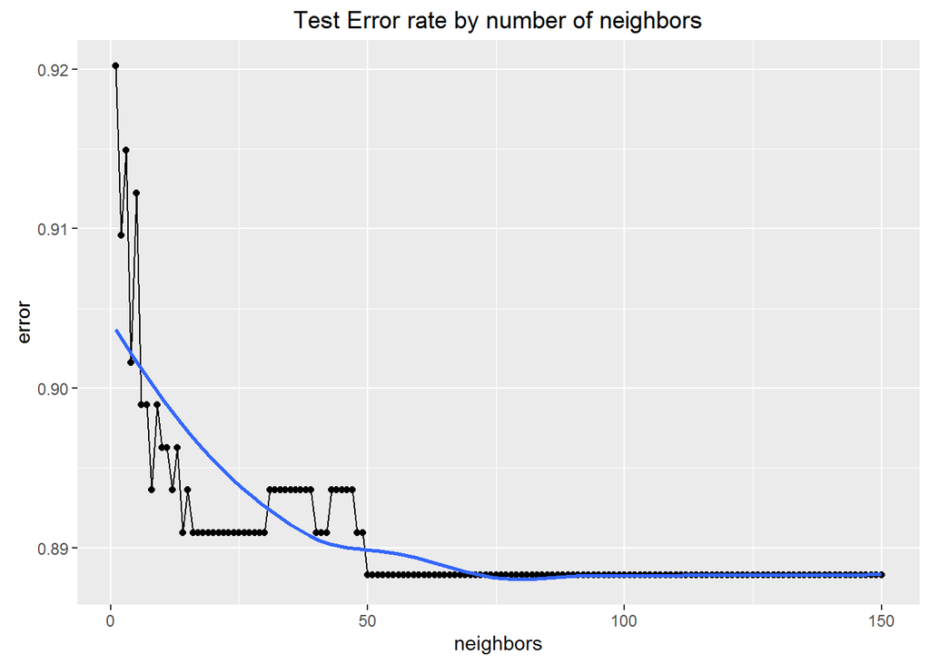

```r
knnResults.df <- data.frame(knnResults)
colnames(knnResults.df) <- c("neighbors", "error")
ggplot(knnResults.df, aes(neighbors, error)) +
    geom_point() + geom_line() +
    geom_smooth(se = F) +
    ggtitle("Test Error rate by number of neighbors")
```

I was curious about what the error rate graphs looked like vs the number of neighbors, so I made this. the graph doesn’t look how I expected it to, so I think that I may have done something wrong.

# LDA

```r
ldaTesting.df <- testingData.df
ldaModel <- lda(Allstar.next~salary * AB * H * B2 * B3, data = trainingData.df)
ldaModel
```

```
## Call:
## lda(Allstar.next ~ salary * AB * H * B2 * B3, data = trainingData.df)
##
## Prior probabilities of groups:
##     FALSE      TRUE
## 0.8989515 0.1010485
##
## Group means:
##        salary       AB         H       B2       B3  salary:AB  salary:H
## FALSE 1715977 324.7323  86.24334 16.61967 1.889079  714015053 195354103
## TRUE  4165734 512.3856 149.20753 28.86470 3.185148 2173661480 646221714
##           AB:H salary:B2     AB:B2     H:B2 salary:B3     AB:B3     H:B3
## FALSE 36563.94  39112407  7065.133 1934.890   3431383  814.0763 223.0205
## TRUE  80921.65 124466900 15604.309 4611.011  10800286 1749.6378 514.1953
##          B2:B3  salary:AB:H salary:AB:B2 salary:H:B2   AB:H:B2
## FALSE 41.35014  93911207315  18850622402  5272257897  933303.7
## TRUE  95.24720 353852445948  67770646380 20358695613 2572570.7
##       salary:AB:B3 salary:H:B3  AB:H:B3 salary:B2:B3 AB:B2:B3   H:B2:B3
## FALSE   1660681160   463933566 108947.5     90114624 20210.08  5637.339
## TRUE    5994366598  1797208916 291883.6    331654254 53748.89 15955.518
##       salary:AB:H:B2 salary:AB:H:B3 salary:AB:B2:B3 salary:H:B2:B3
## FALSE   2.720977e+12   2.416382e+11     46975323354    13309833001
## TRUE    1.139067e+13   1.028358e+12    187805027152    56693167944
##       AB:H:B2:B3 salary:AB:H:B2:B3
## FALSE    2957405      7.248366e+12
## TRUE     9201339      3.275819e+13
##
## Coefficients of linear discriminants:
##                             LD1
## salary             7.737241e-08
## AB                 6.740891e-03
## H                 -2.571352e-02
## B2                 2.870267e-02
## B3                 2.041660e-01
## salary:AB         -2.409570e-09
## salary:H           9.651425e-09
## AB:H               1.920956e-05
## salary:B2          1.289641e-09
## AB:B2             -5.744145e-04
## H:B2               1.530971e-03
## salary:B3          1.310207e-07
## AB:B3             -1.537309e-03
## H:B3               3.841266e-04
## B2:B3             -1.131558e-02
## salary:AB:H        6.031676e-13
## salary:AB:B2       4.807872e-11
## salary:H:B2       -2.274469e-10
## AB:H:B2            7.329415e-07
## salary:AB:B3       1.020481e-10
## salary:H:B3       -2.525725e-09
## AB:H:B3            6.312743e-06
## salary:B2:B3      -7.736585e-09
## AB:B2:B3           6.713642e-05
## H:B2:B3            2.594406e-05
## salary:AB:H:B2     8.404697e-15
## salary:AB:H:B3     2.434202e-12
## salary:AB:B2:B3   -6.754994e-14
## salary:H:B2:B3     1.192459e-10
## AB:H:B2:B3        -3.210528e-07
## salary:AB:H:B2:B3 -1.256133e-13
```

```r
summary(ldaModel)
```

```
##         Length Class  Mode
## prior    2     -none- numeric
## counts   2     -none- numeric
## means   62     -none- numeric
## scaling 31     -none- numeric
## lev      2     -none- character
## svd      1     -none- numeric
## N        1     -none- numeric
## call     3     -none- call
## terms    3     terms  call
## xlevels  0     -none- list
```

```r
ldaPredictions <- predict(ldaModel, testingData.df)

preds <- ldaPredictions$class
ldaTesting.df <- testingData.df %>%
  mutate(ldaPredictions = preds)

with(ldaTesting.df, table(Allstar.next, ldaPredictions))
```

```
##             ldaPredictions
## Allstar.next FALSE TRUE
##        FALSE   317   17
##        TRUE     27   15
```

```r
truePositives <- sum(ldaTesting.df$Allstar.next == T)
falsePositves <- sum(ldaTesting.df$Allstar.next == F & ldaTesting.df$ldaPredictions == T)
trueNegatives <- sum(ldaTesting.df$Allstar.next == F)
falseNegatives <- sum(ldaTesting.df$Allstar.next == T & ldaTesting.df$ldaPredictions == F)
correctPositives <- sum(ldaTesting.df$Allstar.next == T & ldaTesting.df$ldaPredictions == T)

totalValueLDA <- (falseNegatives * 20) + (falsePositves * 50) - (correctPositives * 10)
```

This block is very similar to the logistic block, keeping the error rates and the scores from the scoring matrix for further use.

# Results

```r
# look and see what wins
totalValueLDA
```

```
## [1] 1240
```

```r
totalValueknn
```

```
## [1] 820
```

```r
totalValueLogistic
```

```
## [1] 810
```

Got the scores from the three types of models, so we can take a look at which one to use.

## Application

Seeing that logistic regression scored the best, we want to train the logistic model on as much data as possible, including all the data that we used to compare the models

```r
trainingData.df <- subset(allData.df, yearID < 2012 & !is.null(Allstar.next) & !is.null(salary) & !is.null(AB)) # get the data to use to make the final model
logisticRegrssionModel <- glm(Allstar.next ~ salary * AB * H * B2 * B3, family = binomial, data = trainingData.df)
summary(logisticRegrssionModel)
```

```
##
## Call:
## glm(formula = Allstar.next ~ salary * AB * H * B2 * B3, family = binomial,
##     data = trainingData.df)
##
## Deviance Residuals:
##     Min       1Q   Median       3Q      Max
## -1.7305  -0.4609  -0.2331  -0.1237   3.4020
##
## Coefficients:
##                     Estimate Std. Error z value Pr(>|z|)
## (Intercept)       -6.268e+00  6.740e-01  -9.299   <2e-16 ***
## salary             2.646e-07  1.008e-07   2.624   0.0087 **
## AB                 4.738e-03  5.108e-03   0.928   0.3536
## H                  2.583e-02  2.405e-02   1.074   0.2827
## B2                -2.750e-02  7.356e-02  -0.374   0.7085
## B3                 4.581e-01  4.215e-01   1.087   0.2771
## salary:AB         -1.411e-09  8.721e-10  -1.617   0.1058
## salary:H           2.893e-09  4.287e-09   0.675   0.4998
## AB:H              -1.944e-05  2.766e-05  -0.703   0.4821
## salary:B2          9.635e-09  1.364e-08   0.706   0.4800
## AB:B2             -1.745e-04  2.187e-04  -0.798   0.4248
## H:B2               7.935e-04  8.236e-04   0.963   0.3353
## salary:B3          1.131e-07  1.043e-07   1.084   0.2783
## AB:B3             -1.686e-03  1.572e-03  -1.073   0.2834
## H:B3              -4.900e-03  6.957e-03  -0.704   0.4813
## B2:B3             -9.670e-03  2.827e-02  -0.342   0.7323
## salary:AB:H        1.980e-12  4.936e-12   0.401   0.6882
## salary:AB:B2       4.845e-12  3.752e-11   0.129   0.8972
## salary:H:B2       -1.349e-10  1.371e-10  -0.984   0.3252
## AB:H:B2           -5.168e-08  9.534e-07  -0.054   0.9568
## salary:AB:B3      -1.492e-10  3.708e-10  -0.402   0.6873
## salary:H:B3       -7.519e-10  1.692e-09  -0.444   0.6567
## AB:H:B3            1.289e-05  8.480e-06   1.520   0.1284
## salary:B2:B3      -7.674e-09  6.981e-09  -1.099   0.2716
## AB:B2:B3           5.656e-05  6.804e-05   0.831   0.4058
## H:B2:B3            1.095e-04  2.459e-04   0.445   0.6562
## salary:AB:H:B2     7.793e-14  1.598e-13   0.488   0.6259
## salary:AB:H:B3     1.145e-12  1.977e-12   0.579   0.5626
## salary:AB:B2:B3    1.149e-11  1.602e-11   0.717   0.4734
## salary:H:B2:B3     5.187e-11  5.702e-11   0.910   0.3630
## AB:H:B2:B3        -3.964e-07  3.194e-07  -1.241   0.2145
## salary:AB:H:B2:B3 -8.187e-14  7.526e-14  -1.088   0.2767
## ---
## Signif. codes:  0 '***' 0.001 '**' 0.01 '*' 0.05 '.' 0.1 ' ' 1
##
## (Dispersion parameter for binomial family taken to be 1)
##
##     Null deviance: 6633.2  on 10103  degrees of freedom
## Residual deviance: 5074.3  on 10072  degrees of freedom
## AIC: 5138.3
##
## Number of Fisher Scoring iterations: 7
```

```r
logisticRegressionProb <- predict(logisticRegrssionModel, newdata = newData.df)
allStarThreshold <- .5
logisticTesting.df <- newData.df
logisticTesting.df <- mutate(newData.df, logisticBinaryPrediction = ifelse(logisticRegressionProb > allStarThreshold, TRUE, FALSE))

with(logisticTesting.df, table(Allstar.next, logisticBinaryPrediction))
```

```
##             logisticBinaryPrediction
## Allstar.next FALSE TRUE
##        FALSE   345    3
##        TRUE     31    4
```

```r
truePositives <- sum(logisticTesting.df$Allstar.next == T)
falsePositves <- sum(logisticTesting.df$Allstar.next == F & logisticTesting.df$logisticBinaryPrediction == T)
trueNegatives <- sum(logisticTesting.df$Allstar.next == F)
falseNegatives <- sum(logisticTesting.df$Allstar.next == T & logisticTesting.df$logisticBinaryPrediction == F)
correctPositives <- sum(logisticTesting.df$Allstar.next == T & logisticTesting.df$logisticBinaryPrediction == T)

totalValueLogistic <- (falseNegatives * 20) + (falsePositves * 50) - (correctPositives * 10)
totalValueLogistic
```

```
## [1] 730
```

Not great, but not too bad. Better than the score that caused us to pick the model that we did, so that’s good!